Brian BERNARD

# Portfolio : créations pédagogiques

Les créations proposées dans ce portfolio ont toutes été réalisées par mes propres soins.

## I- Créations numériques

#### A- Audition interactive de l'effet de la numérisation d'un son

**En savoir plus**

**En bref :** Des graphiques illustrent de façon interactive l'effet de l'échantillonnage puis de la quantification d'un signal sur son apparence temporelle. Possibilité d'écouter sur 3 exemples audio l'effet de la numérisation, selon les paramètres d'échantillonnage et de quantification choisis.

#### B- Audition interactive de la notion d'harmonie musicale

**En savoir plus**

**En bref :** Émulation d'un synthétiseur via python, puis tracé de spectre de sons selon la note choisie. Possibilité de composer ses propres accords, de les écouter, tout en voyant le spectre et l'enregistrement du signal audio.

#### C- Modélisation interactive de la notion de réactif limitant

**En savoir plus**

**En bref :** Simulation 2D à l'échelle microscopique de la réaction chimique (faite en TP en parallèle) entre l'ion hydroxyde et l'hydron. Mise en évidence de la notion de réactif limitant. Notebook servant d'aide visuelle aux élèves ayant du mal à passer du modèle du "sandwich" aux espèces chimiques.

#### D- Modélisation de la notion d'équilibre chimique

**En savoir plus**

Vidéo montrant le fonctionnement du script :

[figure not shown]

**En bref :** Numériquement on peut altérer la constante de cinétique de réaction en paramétrant la probabilité qu'un choc entre molécules soit efficace. De la sorte, on peut rendre la réaction dans le sens indirect moins probable que la réaction dans le sens direct et aboutir à un équilibre, dont on peut anticiper les proportions de chaque espèce facilement.

#### E- TP Chronophotographie à partir de coordonnées GPS Élève

**En savoir plus**

Enregistrement des coordonnées GPS Élève durant un mouvement (à vélo, trajet en voiture, etc.) grâce à Phyphox. Sur une carte couvrant 20km à la ronde autour du Lycée, tracé des points de l'acquisition puis export de la chronophotographie superposée à la carte.

Pour un trajet de 15 minutes en voiture en campagne, la chronophotographie est produite en moins de 10 secondes sur un ordinateur du lycée.

Zoom sur le résultat du script sur un exemple :

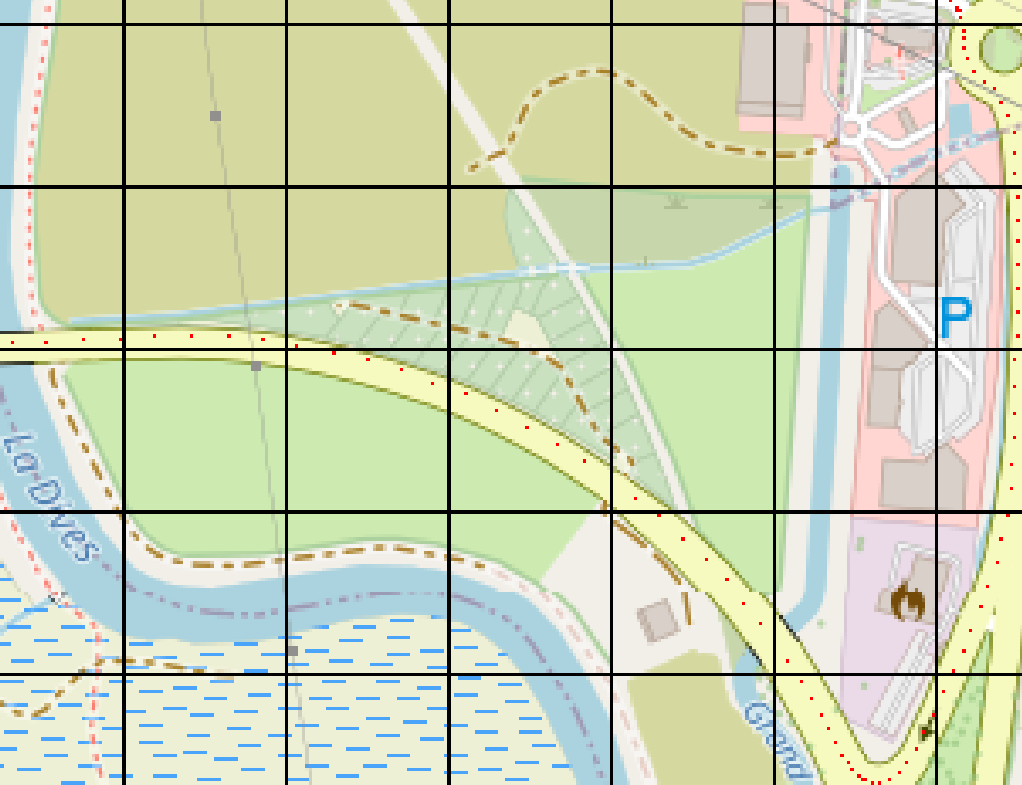

#### F- Et bien d'autres encore...

**En savoir plus**

Édition de capsules vidéo dans le cadre d'un fonctionnement en classe inversée. Réalisation d'animations illustrant des trajectoires complexes (à partir de 1:02 sur la vidéo).

[figure not shown]

Jeu d'entraînement (.exe) aux conversions d'unités, aux questions générées procéduralement (compatible à l'exécution sous wine) :

téléchargement de l'exécutable via ce lien : https://drive.google.com/file/d/1QCscbyRf5n5VkR7nCOo21kpiTJwlhvRo/view?usp=drive_link

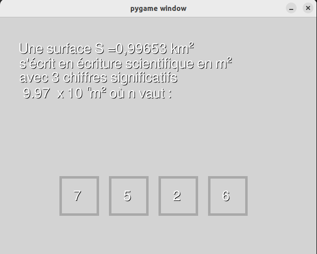

En une heure, réalisation pour un ami titulaire d'un poste en CPGE (PCSI) d'un script produisant une animation. Le but était d'éclaircir la différence entre représentation temporelle et spatiale d'une onde progressive. Vidéo de l'animation :

[figure not shown]

Moins travaillés pour le moment, j'ai également un bon nombre de scripts interactifs destinés à l'enseignement de notions au programme dans l'enseignement supérieur. Ces scripts ont été écrits antérieurement à septembre 2023 : https://drive.google.com/drive/folders/1N8ifid5EW94_goegpml-jf6QhFesFa3J

## II- Créations expérimentales

#### A- Petite chambre à brouillard

**En savoir plus**

Pour démonstration en Enseignement Scientifique de la notion de désintégration radioactive, construction d'une petite chambre à brouillard. Après plusieurs prototypes, le refroidissement à eau via une pompe d'aquarium dans un bain de glace est la solution la plus performante pour refroidir les modules Peltier. Telle que présentée aux élèves, dans la démonstration vidéo le circuit haute tension est volontairement mis de côté, et aucune source radioactive n'est introduite. Le mouchoir est imbibé d'isopropanol.

NB : La vidéo est une illustration du montage et non un support pédagogique destiné aux élèves.

[figure not shown]

#### B- Modulateur Spatial de Lumière fait maison

**En savoir plus**

Avec un ancien vidéoprojecteur tri-LCD, réalisation d'un SLM à l'aide d'un des petits écrans LCD. Le vidéoprojecteur apparaît comme un vidéoprojecteur à n'importe quel ordinateur y étant connecté. Les élèves peuvent donc vidéoprojeter n'importe quelle diapositive de leur conception depuis l'ordinateur, et observer de façon dynamique la transformée de Fourier optique de cet objet.

[figure not shown]

#### C- Mesure de la vitesse de la lumière par temps de vol sur 2m de distance

**En savoir plus**

Pour illustration de la vitesse de la lumière auprès d'élèves en 2nde, illustration du temps de vol de la lumière sur 2 mètres. Le circuit de la diode laser est alimenté à 1MHz par des impulsions de temps de montée d'environ 5 ns. Le repère de lecture du temps de réception de l'impulsion par la photodiode rapide est fait à la demi-amplitude montante pour une meilleur sensibilité. Erreur relative d'environ 10% sur la mesure de c. Le montage électrique a été fait dans la limite de mes outils et le montage optique dans la limite des outils de mon lycée.

[figure not shown]

NB : la vidéo a été tournée à destination d'un ami, il s'agit d'une illustration du montage et non un support pédagogique destiné aux élèves.

[figure not shown]

#### D- Petites expériences originales...

**En savoir plus**

Spectre de raie d'un éclair

Grâce à une raquette électrique à moustiques, obtention du spectre visible d'un éclair.

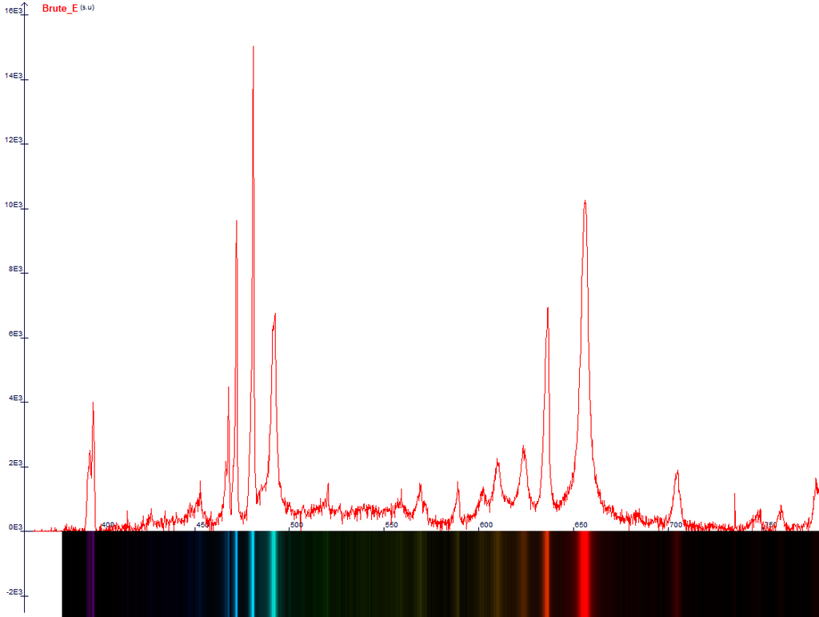

Palier de changement d'état du thymol suivi au thermocouple à l'aide d'un dispositif d'ExAO arduino nano. (Les thermocouples du lycée prévus pour les élèves étaient trop volumineux pour cette expérience)

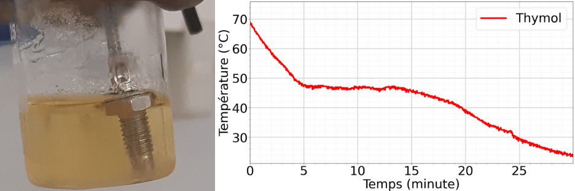

Ce portfolio n'est pas exhaustif, il ne rend pas compte par exemple des montages réalisés que j'ai offert à des amis (machine CNC, interférences sur film de savon "dansant" au rythme de la musique, etc.).

**Contact :** brian.bernard[at]ac-normandie.fr ou brian.bernard[at]ens-paris-saclay.fr